# Optimal Treatment Analysis

## Outcome Variable

**Outcome Variable:** ever_stunted

## Predictor Variables

**Intervention Variable:** nrooms

**Adjustment Set:**

- arm
- sex
- W_mage
- meducyrs
- feducyrs
- hhwealth_quart
- hfoodsec
- W_mhtcm
- W_nchldlt5
- W_parity
- impfloor
- impsan
- safeh20
- delta_W_mage
- delta_meducyrs
- delta_feducyrs
- delta_hhwealth_quart
- delta_hfoodsec
- delta_W_mhtcm
- delta_W_nchldlt5
- delta_W_parity
- delta_impfloor
- delta_impsan
- delta_safeh20

## Stratifying Variables

The analysis was stratified on these variable(s):

- agecat
- studyid
- country

## Data Summary

| agecat | studyid | country | nrooms | ever_stunted | n_cell | n |
| --- | --- | --- | --- | --- | --- | --- |
| 0-24 months | ki0047075b-MAL-ED | BANGLADESH | 4+ | 0 | 8 | 242 |
| 0-24 months | ki0047075b-MAL-ED | BANGLADESH | 4+ | 1 | 4 | 242 |
| 0-24 months | ki0047075b-MAL-ED | BANGLADESH | 1 | 0 | 56 | 242 |
| 0-24 months | ki0047075b-MAL-ED | BANGLADESH | 1 | 1 | 96 | 242 |
| 0-24 months | ki0047075b-MAL-ED | BANGLADESH | 2 | 0 | 19 | 242 |
| 0-24 months | ki0047075b-MAL-ED | BANGLADESH | 2 | 1 | 31 | 242 |
| 0-24 months | ki0047075b-MAL-ED | BANGLADESH | 3 | 0 | 11 | 242 |
| 0-24 months | ki0047075b-MAL-ED | BANGLADESH | 3 | 1 | 17 | 242 |
| 0-24 months | ki0047075b-MAL-ED | BRAZIL | 4+ | 0 | 99 | 210 |
| 0-24 months | ki0047075b-MAL-ED | BRAZIL | 4+ | 1 | 28 | 210 |
| 0-24 months | ki0047075b-MAL-ED | BRAZIL | 1 | 0 | 4 | 210 |
| 0-24 months | ki0047075b-MAL-ED | BRAZIL | 1 | 1 | 0 | 210 |
| 0-24 months | ki0047075b-MAL-ED | BRAZIL | 2 | 0 | 16 | 210 |
| 0-24 months | ki0047075b-MAL-ED | BRAZIL | 2 | 1 | 4 | 210 |
| 0-24 months | ki0047075b-MAL-ED | BRAZIL | 3 | 0 | 42 | 210 |
| 0-24 months | ki0047075b-MAL-ED | BRAZIL | 3 | 1 | 17 | 210 |
| 0-24 months | ki0047075b-MAL-ED | INDIA | 4+ | 0 | 9 | 235 |
| 0-24 months | ki0047075b-MAL-ED | INDIA | 4+ | 1 | 16 | 235 |
| 0-24 months | ki0047075b-MAL-ED | INDIA | 1 | 0 | 39 | 235 |
| 0-24 months | ki0047075b-MAL-ED | INDIA | 1 | 1 | 45 | 235 |
| 0-24 months | ki0047075b-MAL-ED | INDIA | 2 | 0 | 21 | 235 |
| 0-24 months | ki0047075b-MAL-ED | INDIA | 2 | 1 | 57 | 235 |
| 0-24 months | ki0047075b-MAL-ED | INDIA | 3 | 0 | 22 | 235 |
| 0-24 months | ki0047075b-MAL-ED | INDIA | 3 | 1 | 26 | 235 |
| 0-24 months | ki0047075b-MAL-ED | NEPAL | 4+ | 0 | 88 | 236 |
| 0-24 months | ki0047075b-MAL-ED | NEPAL | 4+ | 1 | 43 | 236 |
| 0-24 months | ki0047075b-MAL-ED | NEPAL | 1 | 0 | 33 | 236 |
| 0-24 months | ki0047075b-MAL-ED | NEPAL | 1 | 1 | 19 | 236 |
| 0-24 months | ki0047075b-MAL-ED | NEPAL | 2 | 0 | 22 | 236 |
| 0-24 months | ki0047075b-MAL-ED | NEPAL | 2 | 1 | 9 | 236 |

[output cut: 354 more lines]

The following strata were considered:

- agecat: 0-24 months, studyid: ki0047075b-MAL-ED, country: BANGLADESH
- agecat: 0-24 months, studyid: ki0047075b-MAL-ED, country: BRAZIL
- agecat: 0-24 months, studyid: ki0047075b-MAL-ED, country: INDIA
- agecat: 0-24 months, studyid: ki0047075b-MAL-ED, country: NEPAL
- agecat: 0-24 months, studyid: ki0047075b-MAL-ED, country: PERU
- agecat: 0-24 months, studyid: ki0047075b-MAL-ED, country: SOUTH AFRICA
- agecat: 0-24 months, studyid: ki0047075b-MAL-ED, country: TANZANIA, UNITED REPUBLIC OF
- agecat: 0-24 months, studyid: ki1000108-CMC-V-BCS-2002, country: INDIA
- agecat: 0-24 months, studyid: ki1000108-IRC, country: INDIA
- agecat: 0-24 months, studyid: ki1017093b-PROVIDE, country: BANGLADESH
- agecat: 0-24 months, studyid: ki1017093c-NIH-Crypto, country: BANGLADESH
- agecat: 0-24 months, studyid: ki1113344-GMS-Nepal, country: NEPAL
- agecat: 0-24 months, studyid: ki1114097-CONTENT, country: PERU
- agecat: 0-24 months, studyid: ki1135781-COHORTS, country: INDIA
- agecat: 0-24 months, studyid: kiGH5241-JiVitA-3, country: BANGLADESH
- agecat: 0-24 months, studyid: kiGH5241-JiVitA-4, country: BANGLADESH
- agecat: 0-6 months, studyid: ki0047075b-MAL-ED, country: BANGLADESH
- agecat: 0-6 months, studyid: ki0047075b-MAL-ED, country: BRAZIL
- agecat: 0-6 months, studyid: ki0047075b-MAL-ED, country: INDIA
- agecat: 0-6 months, studyid: ki0047075b-MAL-ED, country: NEPAL
- agecat: 0-6 months, studyid: ki0047075b-MAL-ED, country: PERU
- agecat: 0-6 months, studyid: ki0047075b-MAL-ED, country: SOUTH AFRICA
- agecat: 0-6 months, studyid: ki0047075b-MAL-ED, country: TANZANIA, UNITED REPUBLIC OF
- agecat: 0-6 months, studyid: ki1000108-CMC-V-BCS-2002, country: INDIA
- agecat: 0-6 months, studyid: ki1000108-IRC, country: INDIA
- agecat: 0-6 months, studyid: ki1017093b-PROVIDE, country: BANGLADESH
- agecat: 0-6 months, studyid: ki1017093c-NIH-Crypto, country: BANGLADESH
- agecat: 0-6 months, studyid: ki1113344-GMS-Nepal, country: NEPAL
- agecat: 0-6 months, studyid: ki1114097-CONTENT, country: PERU
- agecat: 0-6 months, studyid: ki1135781-COHORTS, country: INDIA
- agecat: 0-6 months, studyid: kiGH5241-JiVitA-3, country: BANGLADESH
- agecat: 0-6 months, studyid: kiGH5241-JiVitA-4, country: BANGLADESH
- agecat: 6-24 months, studyid: ki0047075b-MAL-ED, country: BANGLADESH
- agecat: 6-24 months, studyid: ki0047075b-MAL-ED, country: BRAZIL
- agecat: 6-24 months, studyid: ki0047075b-MAL-ED, country: INDIA
- agecat: 6-24 months, studyid: ki0047075b-MAL-ED, country: NEPAL
- agecat: 6-24 months, studyid: ki0047075b-MAL-ED, country: PERU
- agecat: 6-24 months, studyid: ki0047075b-MAL-ED, country: SOUTH AFRICA
- agecat: 6-24 months, studyid: ki0047075b-MAL-ED, country: TANZANIA, UNITED REPUBLIC OF
- agecat: 6-24 months, studyid: ki1000108-CMC-V-BCS-2002, country: INDIA
- agecat: 6-24 months, studyid: ki1000108-IRC, country: INDIA
- agecat: 6-24 months, studyid: ki1017093b-PROVIDE, country: BANGLADESH
- agecat: 6-24 months, studyid: ki1017093c-NIH-Crypto, country: BANGLADESH
- agecat: 6-24 months, studyid: ki1113344-GMS-Nepal, country: NEPAL
- agecat: 6-24 months, studyid: ki1114097-CONTENT, country: PERU
- agecat: 6-24 months, studyid: ki1135781-COHORTS, country: INDIA
- agecat: 6-24 months, studyid: kiGH5241-JiVitA-3, country: BANGLADESH
- agecat: 6-24 months, studyid: kiGH5241-JiVitA-4, country: BANGLADESH

### Dropped Strata

Some strata were dropped due to rare outcomes:

- agecat: 0-24 months, studyid: ki0047075b-MAL-ED, country: BANGLADESH
- agecat: 0-24 months, studyid: ki0047075b-MAL-ED, country: BRAZIL
- agecat: 0-24 months, studyid: ki0047075b-MAL-ED, country: PERU
- agecat: 0-24 months, studyid: ki1000108-CMC-V-BCS-2002, country: INDIA
- agecat: 0-24 months, studyid: ki1000108-IRC, country: INDIA
- agecat: 0-6 months, studyid: ki0047075b-MAL-ED, country: BANGLADESH
- agecat: 0-6 months, studyid: ki0047075b-MAL-ED, country: BRAZIL
- agecat: 0-6 months, studyid: ki0047075b-MAL-ED, country: NEPAL
- agecat: 0-6 months, studyid: ki1017093b-PROVIDE, country: BANGLADESH
- agecat: 6-24 months, studyid: ki0047075b-MAL-ED, country: BANGLADESH
- agecat: 6-24 months, studyid: ki0047075b-MAL-ED, country: BRAZIL
- agecat: 6-24 months, studyid: ki0047075b-MAL-ED, country: NEPAL
- agecat: 6-24 months, studyid: ki0047075b-MAL-ED, country: PERU
- agecat: 6-24 months, studyid: ki0047075b-MAL-ED, country: SOUTH AFRICA
- agecat: 6-24 months, studyid: ki0047075b-MAL-ED, country: TANZANIA, UNITED REPUBLIC OF
- agecat: 6-24 months, studyid: ki1000108-CMC-V-BCS-2002, country: INDIA
- agecat: 6-24 months, studyid: ki1000108-IRC, country: INDIA
- agecat: 6-24 months, studyid: ki1017093b-PROVIDE, country: BANGLADESH
- agecat: 6-24 months, studyid: ki1114097-CONTENT, country: PERU

## Methods Detail

We’re interested in the causal parameters $E[Y_a]$ for all values of $a \in \mathcal{A}$. These parameters represent the mean outcome if, possibly contrary to fact, we intervened to set all units to have $A=a$. Under the randomization and positivity assumptions, these are identified by the statistical parameters $\psi_a=E_W[E_{Y|A,W}(Y|A=a,W)]$. In addition, we’re interested in the mean of $Y$, $E[Y]$ under no intervention (the observed mean). We will estimate these parameters by using SuperLearner to fit the relevant likelihood factors – $E_{Y|A,W}(Y|A=a,W)$ and $p(A=a|W)$, and then updating our likelihood fit using a joint TMLE.

For unadjusted analyses ($W=\{\}$), initial likelihoods were estimated using Lrnr_glm to estimate the simple $E(Y|A)$ and Lrnr_mean to estimate $p(A)$. For adjusted analyses, a small library containing Lrnr_glmnet, Lrnr_xgboost, and Lrnr_mean was used.

Having estimated these parameters, we will then use the delta method to estimate relative risks and attributable risks relative to a prespecified baseline level of $A$.

# Results Detail

## Results Plots

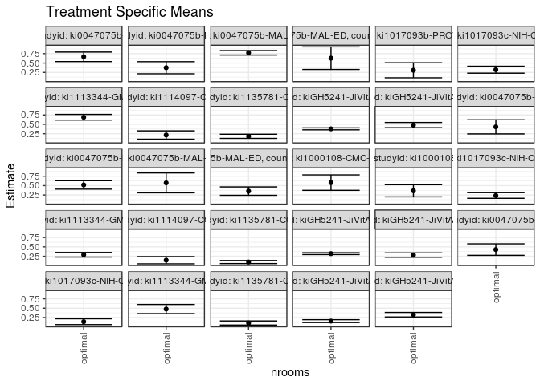

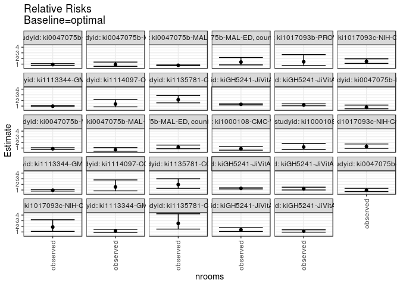

## Results Table

### Parameter: TSM

| agecat | studyid | country | intervention_level | baseline_level | estimate | ci_lower | ci_upper |
| --- | --- | --- | --- | --- | --- | --- | --- |
| 0-24 months | ki0047075b-MAL-ED | INDIA | optimal | NA | 0.6659099 | 0.5398742 | 0.7919456 |
| 0-24 months | ki0047075b-MAL-ED | NEPAL | optimal | NA | 0.3752763 | 0.2138461 | 0.5367065 |
| 0-24 months | ki0047075b-MAL-ED | SOUTH AFRICA | optimal | NA | 0.7716171 | 0.7120658 | 0.8311683 |
| 0-24 months | ki0047075b-MAL-ED | TANZANIA, UNITED REPUBLIC OF | optimal | NA | 0.6296006 | 0.3287283 | 0.9304730 |
| 0-24 months | ki1017093b-PROVIDE | BANGLADESH | optimal | NA | 0.3075846 | 0.1075412 | 0.5076280 |
| 0-24 months | ki1017093c-NIH-Crypto | BANGLADESH | optimal | NA | 0.3229611 | 0.2303024 | 0.4156198 |
| 0-24 months | ki1113344-GMS-Nepal | NEPAL | optimal | NA | 0.6882329 | 0.6124304 | 0.7640353 |
| 0-24 months | ki1114097-CONTENT | PERU | optimal | NA | 0.2154187 | 0.1045207 | 0.3263167 |
| 0-24 months | ki1135781-COHORTS | INDIA | optimal | NA | 0.1820768 | 0.1264540 | 0.2376996 |
| 0-24 months | kiGH5241-JiVitA-3 | BANGLADESH | optimal | NA | 0.3799361 | 0.3536220 | 0.4062503 |
| 0-24 months | kiGH5241-JiVitA-4 | BANGLADESH | optimal | NA | 0.4798893 | 0.4099568 | 0.5498219 |
| 0-6 months | ki0047075b-MAL-ED | INDIA | optimal | NA | 0.4330746 | 0.2451164 | 0.6210328 |
| 0-6 months | ki0047075b-MAL-ED | PERU | optimal | NA | 0.5177159 | 0.4054695 | 0.6299624 |
| 0-6 months | ki0047075b-MAL-ED | SOUTH AFRICA | optimal | NA | 0.5723454 | 0.3082221 | 0.8364687 |
| 0-6 months | ki0047075b-MAL-ED | TANZANIA, UNITED REPUBLIC OF | optimal | NA | 0.3533781 | 0.2419393 | 0.4648170 |
| 0-6 months | ki1000108-CMC-V-BCS-2002 | INDIA | optimal | NA | 0.5797393 | 0.3739298 | 0.7855489 |
| 0-6 months | ki1000108-IRC | INDIA | optimal | NA | 0.3622896 | 0.2012164 | 0.5233628 |
| 0-6 months | ki1017093c-NIH-Crypto | BANGLADESH | optimal | NA | 0.2369044 | 0.1619266 | 0.3118822 |
| 0-6 months | ki1113344-GMS-Nepal | NEPAL | optimal | NA | 0.2907527 | 0.2295028 | 0.3520026 |
| 0-6 months | ki1114097-CONTENT | PERU | optimal | NA | 0.1453921 | 0.0494895 | 0.2412947 |
| 0-6 months | ki1135781-COHORTS | INDIA | optimal | NA | 0.0969160 | 0.0560195 | 0.1378125 |
| 0-6 months | kiGH5241-JiVitA-3 | BANGLADESH | optimal | NA | 0.3202847 | 0.2954824 | 0.3450870 |
| 0-6 months | kiGH5241-JiVitA-4 | BANGLADESH | optimal | NA | 0.2831201 | 0.2249731 | 0.3412671 |
| 6-24 months | ki0047075b-MAL-ED | INDIA | optimal | NA | 0.4280088 | 0.2747238 | 0.5812937 |
| 6-24 months | ki1017093c-NIH-Crypto | BANGLADESH | optimal | NA | 0.1403720 | 0.0628802 | 0.2178638 |
| 6-24 months | ki1113344-GMS-Nepal | NEPAL | optimal | NA | 0.4770995 | 0.3550907 | 0.5991084 |
| 6-24 months | ki1135781-COHORTS | INDIA | optimal | NA | 0.1055846 | 0.0509318 | 0.1602375 |
| 6-24 months | kiGH5241-JiVitA-3 | BANGLADESH | optimal | NA | 0.1563802 | 0.1186574 | 0.1941030 |
| 6-24 months | kiGH5241-JiVitA-4 | BANGLADESH | optimal | NA | 0.3271884 | 0.2668129 | 0.3875639 |

### Parameter: E(Y)

| agecat | studyid | country | intervention_level | baseline_level | estimate | ci_lower | ci_upper |
| --- | --- | --- | --- | --- | --- | --- | --- |
| 0-24 months | ki0047075b-MAL-ED | INDIA | observed | NA | 0.6127660 | 0.5503531 | 0.6751788 |
| 0-24 months | ki0047075b-MAL-ED | NEPAL | observed | NA | 0.3432203 | 0.2825173 | 0.4039234 |
| 0-24 months | ki0047075b-MAL-ED | SOUTH AFRICA | observed | NA | 0.6070039 | 0.5471740 | 0.6668337 |
| 0-24 months | ki0047075b-MAL-ED | TANZANIA, UNITED REPUBLIC OF | observed | NA | 0.8600000 | 0.8169015 | 0.9030985 |
| 0-24 months | ki1017093b-PROVIDE | BANGLADESH | observed | NA | 0.4342857 | 0.3975409 | 0.4710305 |
| 0-24 months | ki1017093c-NIH-Crypto | BANGLADESH | observed | NA | 0.4775726 | 0.4419904 | 0.5131548 |
| 0-24 months | ki1113344-GMS-Nepal | NEPAL | observed | NA | 0.6744186 | 0.6369554 | 0.7118819 |
| 0-24 months | ki1114097-CONTENT | PERU | observed | NA | 0.2930233 | 0.2320422 | 0.3540043 |
| 0-24 months | ki1135781-COHORTS | INDIA | observed | NA | 0.3879792 | 0.3749497 | 0.4010086 |
| 0-24 months | kiGH5241-JiVitA-3 | BANGLADESH | observed | NA | 0.4939352 | 0.4860896 | 0.5017807 |
| 0-24 months | kiGH5241-JiVitA-4 | BANGLADESH | observed | NA | 0.5818282 | 0.5658219 | 0.5978346 |
| 0-6 months | ki0047075b-MAL-ED | INDIA | observed | NA | 0.3404255 | 0.2797123 | 0.4011387 |
| 0-6 months | ki0047075b-MAL-ED | PERU | observed | NA | 0.4485294 | 0.3893160 | 0.5077428 |
| 0-6 months | ki0047075b-MAL-ED | SOUTH AFRICA | observed | NA | 0.3891051 | 0.3293816 | 0.4488285 |
| 0-6 months | ki0047075b-MAL-ED | TANZANIA, UNITED REPUBLIC OF | observed | NA | 0.4080000 | 0.3469565 | 0.4690435 |
| 0-6 months | ki1000108-CMC-V-BCS-2002 | INDIA | observed | NA | 0.5108696 | 0.4597270 | 0.5620121 |
| 0-6 months | ki1000108-IRC | INDIA | observed | NA | 0.4264706 | 0.3784228 | 0.4745184 |
| 0-6 months | ki1017093c-NIH-Crypto | BANGLADESH | observed | NA | 0.3021108 | 0.2694011 | 0.3348205 |
| 0-6 months | ki1113344-GMS-Nepal | NEPAL | observed | NA | 0.2774086 | 0.2416141 | 0.3132032 |
| 0-6 months | ki1114097-CONTENT | PERU | observed | NA | 0.2232558 | 0.1674626 | 0.2790491 |
| 0-6 months | ki1135781-COHORTS | INDIA | observed | NA | 0.1906412 | 0.1799566 | 0.2013259 |
| 0-6 months | kiGH5241-JiVitA-3 | BANGLADESH | observed | NA | 0.4109064 | 0.4034556 | 0.4183572 |
| 0-6 months | kiGH5241-JiVitA-4 | BANGLADESH | observed | NA | 0.3474692 | 0.3322601 | 0.3626783 |
| 6-24 months | ki0047075b-MAL-ED | INDIA | observed | NA | 0.4129032 | 0.3351414 | 0.4906651 |
| 6-24 months | ki1017093c-NIH-Crypto | BANGLADESH | observed | NA | 0.2628458 | 0.2244546 | 0.3012371 |
| 6-24 months | ki1113344-GMS-Nepal | NEPAL | observed | NA | 0.5610329 | 0.5138522 | 0.6082135 |
| 6-24 months | ki1135781-COHORTS | INDIA | observed | NA | 0.2665531 | 0.2530304 | 0.2800757 |
| 6-24 months | kiGH5241-JiVitA-3 | BANGLADESH | observed | NA | 0.2173210 | 0.2079509 | 0.2266911 |
| 6-24 months | kiGH5241-JiVitA-4 | BANGLADESH | observed | NA | 0.3784303 | 0.3598372 | 0.3970234 |

### Parameter: RR

| agecat | studyid | country | intervention_level | baseline_level | estimate | ci_lower | ci_upper |
| --- | --- | --- | --- | --- | --- | --- | --- |
| 0-24 months | ki0047075b-MAL-ED | INDIA | observed | optimal | 0.9201935 | 0.7820436 | 1.0827480 |
| 0-24 months | ki0047075b-MAL-ED | NEPAL | observed | optimal | 0.9145805 | 0.6127761 | 1.3650295 |
| 0-24 months | ki0047075b-MAL-ED | SOUTH AFRICA | observed | optimal | 0.7866647 | 0.7293221 | 0.8485158 |
| 0-24 months | ki0047075b-MAL-ED | TANZANIA, UNITED REPUBLIC OF | observed | optimal | 1.3659453 | 0.8585195 | 2.1732839 |
| 0-24 months | ki1017093b-PROVIDE | BANGLADESH | observed | optimal | 1.4119229 | 0.7432897 | 2.6820312 |
| 0-24 months | ki1017093c-NIH-Crypto | BANGLADESH | observed | optimal | 1.4787310 | 1.1291153 | 1.9366007 |
| 0-24 months | ki1113344-GMS-Nepal | NEPAL | observed | optimal | 0.9799279 | 0.8900894 | 1.0788340 |
| 0-24 months | ki1114097-CONTENT | PERU | observed | optimal | 1.3602499 | 0.8592100 | 2.1534665 |
| 0-24 months | ki1135781-COHORTS | INDIA | observed | optimal | 2.1308544 | 1.5729035 | 2.8867254 |
| 0-24 months | kiGH5241-JiVitA-3 | BANGLADESH | observed | optimal | 1.3000478 | 1.2142363 | 1.3919238 |
| 0-24 months | kiGH5241-JiVitA-4 | BANGLADESH | observed | optimal | 1.2124217 | 1.0532284 | 1.3956766 |
| 0-6 months | ki0047075b-MAL-ED | INDIA | observed | optimal | 0.7860667 | 0.5250235 | 1.1769013 |
| 0-6 months | ki0047075b-MAL-ED | PERU | observed | optimal | 0.8663620 | 0.7181602 | 1.0451473 |
| 0-6 months | ki0047075b-MAL-ED | SOUTH AFRICA | observed | optimal | 0.6798431 | 0.4340337 | 1.0648633 |
| 0-6 months | ki0047075b-MAL-ED | TANZANIA, UNITED REPUBLIC OF | observed | optimal | 1.1545705 | 0.8746543 | 1.5240685 |
| 0-6 months | ki1000108-CMC-V-BCS-2002 | INDIA | observed | optimal | 0.8812057 | 0.6266162 | 1.2392329 |
| 0-6 months | ki1000108-IRC | INDIA | observed | optimal | 1.1771537 | 0.7687871 | 1.8024379 |
| 0-6 months | ki1017093c-NIH-Crypto | BANGLADESH | observed | optimal | 1.2752434 | 0.9461248 | 1.7188490 |
| 0-6 months | ki1113344-GMS-Nepal | NEPAL | observed | optimal | 0.9541051 | 0.8069990 | 1.1280268 |
| 0-6 months | ki1114097-CONTENT | PERU | observed | optimal | 1.5355426 | 0.8448529 | 2.7908894 |
| 0-6 months | ki1135781-COHORTS | INDIA | observed | optimal | 1.9670770 | 1.2930835 | 2.9923759 |
| 0-6 months | kiGH5241-JiVitA-3 | BANGLADESH | observed | optimal | 1.2829412 | 1.1889910 | 1.3843149 |
| 0-6 months | kiGH5241-JiVitA-4 | BANGLADESH | observed | optimal | 1.2272856 | 1.0053823 | 1.4981664 |
| 6-24 months | ki0047075b-MAL-ED | INDIA | observed | optimal | 0.9647074 | 0.7166941 | 1.2985462 |
| 6-24 months | ki1017093c-NIH-Crypto | BANGLADESH | observed | optimal | 1.8724946 | 1.1075377 | 3.1657937 |
| 6-24 months | ki1113344-GMS-Nepal | NEPAL | observed | optimal | 1.1759241 | 0.9317568 | 1.4840757 |
| 6-24 months | ki1135781-COHORTS | INDIA | observed | optimal | 2.5245443 | 1.5083757 | 4.2252895 |
| 6-24 months | kiGH5241-JiVitA-3 | BANGLADESH | observed | optimal | 1.3896967 | 1.0956960 | 1.7625846 |
| 6-24 months | kiGH5241-JiVitA-4 | BANGLADESH | observed | optimal | 1.1566129 | 0.9670604 | 1.3833194 |

### Parameter: PAR

| agecat | studyid | country | intervention_level | baseline_level | estimate | ci_lower | ci_upper |
| --- | --- | --- | --- | --- | --- | --- | --- |
| 0-24 months | ki0047075b-MAL-ED | INDIA | optimal | NA | -0.0531439 | -0.1614394 | 0.0551515 |
| 0-24 months | ki0047075b-MAL-ED | NEPAL | optimal | NA | -0.0320559 | -0.1821834 | 0.1180716 |
| 0-24 months | ki0047075b-MAL-ED | SOUTH AFRICA | optimal | NA | -0.1646132 | -0.2143010 | -0.1149254 |
| 0-24 months | ki0047075b-MAL-ED | TANZANIA, UNITED REPUBLIC OF | optimal | NA | 0.2303994 | -0.0596722 | 0.5204710 |
| 0-24 months | ki1017093b-PROVIDE | BANGLADESH | optimal | NA | 0.1267011 | -0.0705340 | 0.3239363 |
| 0-24 months | ki1017093c-NIH-Crypto | BANGLADESH | optimal | NA | 0.1546115 | 0.0678776 | 0.2413454 |
| 0-24 months | ki1113344-GMS-Nepal | NEPAL | optimal | NA | -0.0138143 | -0.0799828 | 0.0523542 |
| 0-24 months | ki1114097-CONTENT | PERU | optimal | NA | 0.0776046 | -0.0217781 | 0.1769872 |
| 0-24 months | ki1135781-COHORTS | INDIA | optimal | NA | 0.2059024 | 0.1502011 | 0.2616036 |
| 0-24 months | kiGH5241-JiVitA-3 | BANGLADESH | optimal | NA | 0.1139990 | 0.0878933 | 0.1401047 |
| 0-24 months | kiGH5241-JiVitA-4 | BANGLADESH | optimal | NA | 0.1019389 | 0.0345731 | 0.1693047 |
| 0-6 months | ki0047075b-MAL-ED | INDIA | optimal | NA | -0.0926491 | -0.2674913 | 0.0821931 |
| 0-6 months | ki0047075b-MAL-ED | PERU | optimal | NA | -0.0691865 | -0.1657068 | 0.0273338 |
| 0-6 months | ki0047075b-MAL-ED | SOUTH AFRICA | optimal | NA | -0.1832404 | -0.4391696 | 0.0726889 |
| 0-6 months | ki0047075b-MAL-ED | TANZANIA, UNITED REPUBLIC OF | optimal | NA | 0.0546219 | -0.0438380 | 0.1530817 |
| 0-6 months | ki1000108-CMC-V-BCS-2002 | INDIA | optimal | NA | -0.0688698 | -0.2666312 | 0.1288917 |
| 0-6 months | ki1000108-IRC | INDIA | optimal | NA | 0.0641810 | -0.0900776 | 0.2184395 |
| 0-6 months | ki1017093c-NIH-Crypto | BANGLADESH | optimal | NA | 0.0652064 | -0.0059381 | 0.1363508 |
| 0-6 months | ki1113344-GMS-Nepal | NEPAL | optimal | NA | -0.0133441 | -0.0620490 | 0.0353609 |
| 0-6 months | ki1114097-CONTENT | PERU | optimal | NA | 0.0778637 | -0.0101562 | 0.1658835 |
| 0-6 months | ki1135781-COHORTS | INDIA | optimal | NA | 0.0937252 | 0.0526107 | 0.1348398 |
| 0-6 months | kiGH5241-JiVitA-3 | BANGLADESH | optimal | NA | 0.0906217 | 0.0661400 | 0.1151035 |
| 0-6 months | kiGH5241-JiVitA-4 | BANGLADESH | optimal | NA | 0.0643491 | 0.0078932 | 0.1208050 |
| 6-24 months | ki0047075b-MAL-ED | INDIA | optimal | NA | -0.0151055 | -0.1424450 | 0.1122339 |
| 6-24 months | ki1017093c-NIH-Crypto | BANGLADESH | optimal | NA | 0.1224738 | 0.0474932 | 0.1974544 |
| 6-24 months | ki1113344-GMS-Nepal | NEPAL | optimal | NA | 0.0839333 | -0.0265789 | 0.1944456 |
| 6-24 months | ki1135781-COHORTS | INDIA | optimal | NA | 0.1609684 | 0.1059960 | 0.2159409 |
| 6-24 months | kiGH5241-JiVitA-3 | BANGLADESH | optimal | NA | 0.0609408 | 0.0236556 | 0.0982261 |
| 6-24 months | kiGH5241-JiVitA-4 | BANGLADESH | optimal | NA | 0.0512419 | -0.0074330 | 0.1099168 |

### Parameter: PAF

| agecat | studyid | country | intervention_level | baseline_level | estimate | ci_lower | ci_upper |
| --- | --- | --- | --- | --- | --- | --- | --- |
| 0-24 months | ki0047075b-MAL-ED | INDIA | optimal | NA | -0.0867279 | -0.2787012 | 0.0764241 |
| 0-24 months | ki0047075b-MAL-ED | NEPAL | optimal | NA | -0.0933975 | -0.6319174 | 0.2674151 |
| 0-24 months | ki0047075b-MAL-ED | SOUTH AFRICA | optimal | NA | -0.2711897 | -0.3711364 | -0.1785284 |
| 0-24 months | ki0047075b-MAL-ED | TANZANIA, UNITED REPUBLIC OF | optimal | NA | 0.2679063 | -0.1647960 | 0.5398668 |
| 0-24 months | ki1017093b-PROVIDE | BANGLADESH | optimal | NA | 0.2917460 | -0.3453704 | 0.6271483 |
| 0-24 months | ki1017093c-NIH-Crypto | BANGLADESH | optimal | NA | 0.3237445 | 0.1143508 | 0.4836313 |
| 0-24 months | ki1113344-GMS-Nepal | NEPAL | optimal | NA | -0.0204832 | -0.1234827 | 0.0730734 |
| 0-24 months | ki1114097-CONTENT | PERU | optimal | NA | 0.2648410 | -0.1638599 | 0.5356324 |
| 0-24 months | ki1135781-COHORTS | INDIA | optimal | NA | 0.5307047 | 0.3642331 | 0.6535867 |
| 0-24 months | kiGH5241-JiVitA-3 | BANGLADESH | optimal | NA | 0.2307975 | 0.1764370 | 0.2815699 |
| 0-24 months | kiGH5241-JiVitA-4 | BANGLADESH | optimal | NA | 0.1752044 | 0.0505384 | 0.2835016 |
| 0-6 months | ki0047075b-MAL-ED | INDIA | optimal | NA | -0.2721567 | -0.9046766 | 0.1503111 |
| 0-6 months | ki0047075b-MAL-ED | PERU | optimal | NA | -0.1542519 | -0.3924470 | 0.0431971 |
| 0-6 months | ki0047075b-MAL-ED | SOUTH AFRICA | optimal | NA | -0.4709277 | -1.3039684 | 0.0609123 |
| 0-6 months | ki0047075b-MAL-ED | TANZANIA, UNITED REPUBLIC OF | optimal | NA | 0.1338771 | -0.1433088 | 0.3438615 |
| 0-6 months | ki1000108-CMC-V-BCS-2002 | INDIA | optimal | NA | -0.1348089 | -0.5958733 | 0.1930492 |
| 0-6 months | ki1000108-IRC | INDIA | optimal | NA | 0.1504933 | -0.3007503 | 0.4451959 |
| 0-6 months | ki1017093c-NIH-Crypto | BANGLADESH | optimal | NA | 0.2158360 | -0.0569430 | 0.4182153 |
| 0-6 months | ki1113344-GMS-Nepal | NEPAL | optimal | NA | -0.0481026 | -0.2391589 | 0.1134963 |
| 0-6 months | ki1114097-CONTENT | PERU | optimal | NA | 0.3487644 | -0.1836380 | 0.6416913 |
| 0-6 months | ki1135781-COHORTS | INDIA | optimal | NA | 0.4916315 | 0.2266548 | 0.6658174 |
| 0-6 months | kiGH5241-JiVitA-3 | BANGLADESH | optimal | NA | 0.2205410 | 0.1589508 | 0.2776210 |
| 0-6 months | kiGH5241-JiVitA-4 | BANGLADESH | optimal | NA | 0.1851938 | 0.0053535 | 0.3325174 |
| 6-24 months | ki0047075b-MAL-ED | INDIA | optimal | NA | -0.0365837 | -0.3952955 | 0.2299080 |
| 6-24 months | ki1017093c-NIH-Crypto | BANGLADESH | optimal | NA | 0.4659531 | 0.0970962 | 0.6841234 |
| 6-24 months | ki1113344-GMS-Nepal | NEPAL | optimal | NA | 0.1496050 | -0.0732415 | 0.3261799 |
| 6-24 months | ki1135781-COHORTS | INDIA | optimal | NA | 0.6038889 | 0.3370352 | 0.7633298 |
| 6-24 months | kiGH5241-JiVitA-3 | BANGLADESH | optimal | NA | 0.2804185 | 0.0873381 | 0.4326513 |
| 6-24 months | kiGH5241-JiVitA-4 | BANGLADESH | optimal | NA | 0.1354065 | -0.0340616 | 0.2771012 |